# Comportamiento en el contexto de Redes

George G. Vega Yon

Department of Preventive Medicine University of Southern California 2 de Enero, 2019

[figure not shown]

Antes de partir… retomaremos un modelo que nos faltó revisar

## Stochastic Actor Oriented Models (SOAM, aka Siena)

Los modelos Siena:

- Modelan la co-evolución de la red y el comportamiento.
- A diferencia de los ERGMs (*cross-section*), Siena modela datos dinámicos. Más aun, ponen el foco en el individuo.
- El modelo asume que los cambios en la red o comportamiento ocurren de manera continua (no discreta)–como ocurre con un proceso poisson–y uno a la vez desde el punto de vista del individuo.
- Estos corresponden a los denominados *micro-step*, y hacen que el modelamiento sea en general más sencillo (nos enfocamos en un cambio a la vez)
- Dos funciones principales componen el modelo: $f_i^G(g) = s_{Gi}(g, y)\theta^G$, utilidad que el individuo $i$ obtiene con el estado del grafo $g$, y $f_i^Y(y) = s_{Yi}(g, y)\theta^Y$, utilidad que el mismo individuo obtiene con el estado de la variable $y$.
- De manera similar a los ERGMs, las funciones objetivo son:

  $$\frac{\exp f_i^G(g)}{\sum_{g'\in\mathcal{G}}\exp f_i^G(g')}, \quad
  \frac{\exp f_i^Y(y)}{\sum_{y'\in\mathcal{Y}}\exp f_i^Y(y')}$$

Sección 5 *Model specification* de *Manual for RSiena* (Ripley et al. 2011) para ver una descripción asociada a RSiena, y Snijders, Bunt, and Steglich (2010); Steglich, Snijders, and Pearson (2010) para una introducción más detallada (no tan formal) del modelo.

[figure not shown]

## Autocorrelación

- La I de Moran (Moran 1950): Pregunta, ¿está la variable $X$ correlacionada a nivel espacial?

  $$I={\frac {N}{W}}{\frac {\sum _{i}\sum _{j}w_{ij}(x_{i}-{\bar {x}})(x_{j}-{\bar {x}})}{\sum _{i}(x_{i}-{\bar {x}})^{2}}}$$

  Donde $W$ es una matriz normalizada (*row-normalized*)

## Autocorrelación (Moran -1)

```
## List of 4
##  $ observed: num -1
##  $ expected: num -0.0417
##  $ sd      : num 0.157
##  $ p.value : num 9.43e-10
##  - attr(*, "class")= chr "diffnet_moran"
```

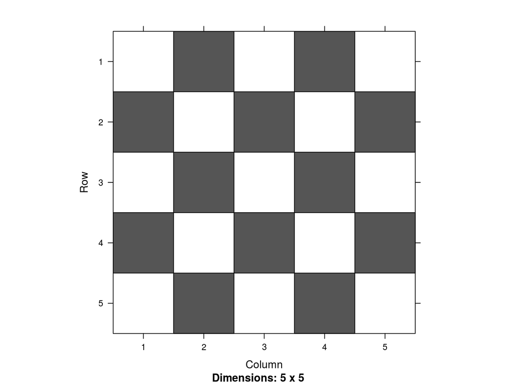

## Autocorrelación (Moran cercano a 1)

```
## List of 4
##  $ observed: num 0.708
##  $ expected: num -0.0667
##  $ sd      : num 0.2
##  $ p.value : num 0.000103
##  - attr(*, "class")= chr "diffnet_moran"
```

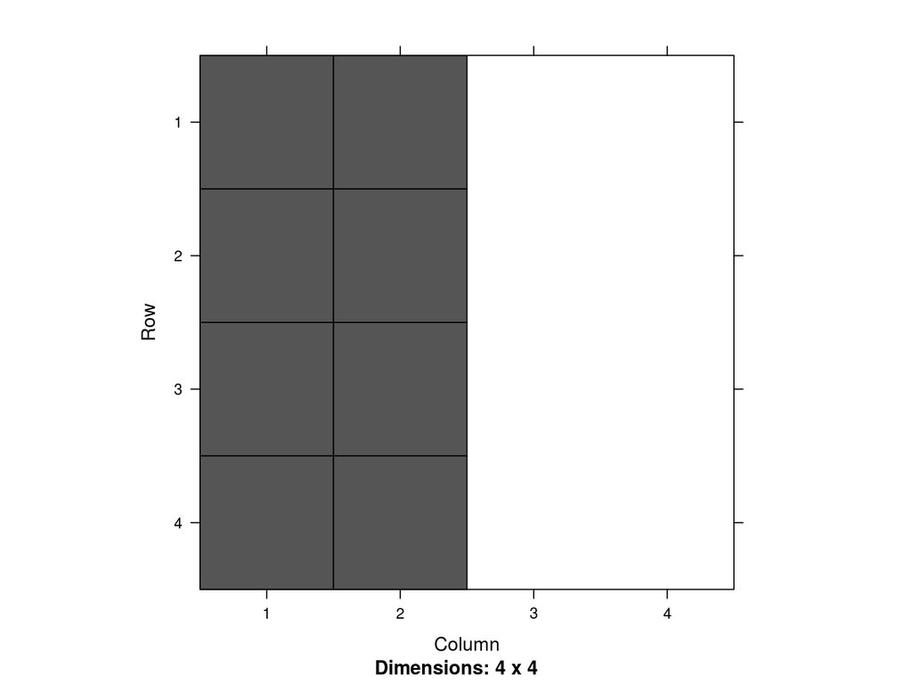

Ejemplo de I de Moran con valor cercano o igual a 1. La matriz fue graficada utilizando el metodo dgCMatrix de la funcion image.

## Autocorrelación (Moran cercano a 0)

```
## List of 4
##  $ observed: num 0.0183
##  $ expected: num -0.00251
##  $ sd      : num 0.0364
##  $ p.value : num 0.568
##  - attr(*, "class")= chr "diffnet_moran"
```

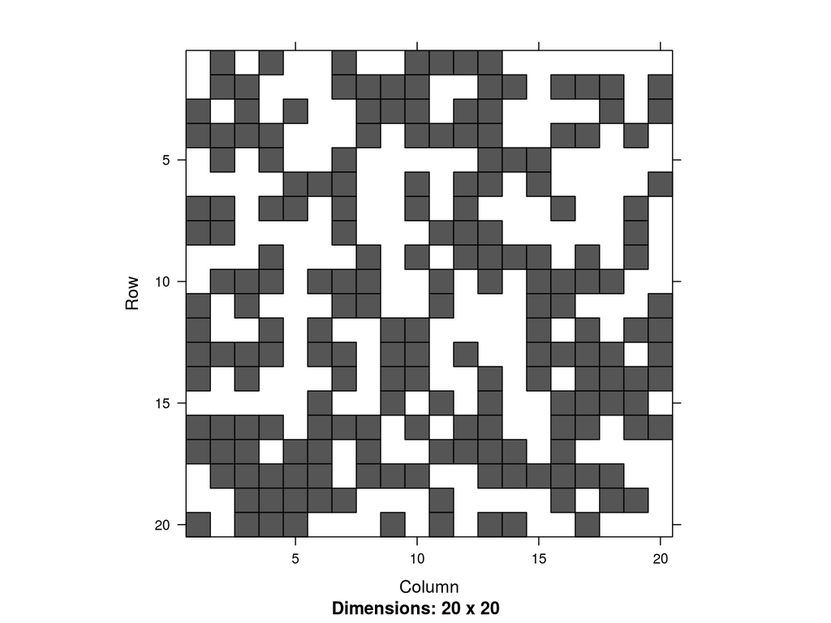

Ejemplo de I de Moran con valor cercano o igual a 0. La matriz fue graficada utilizando el metodo dgCMatrix de la funcion image.

## Modelos de Autocorrelacion Espacial/*Spatial Autocorrelation Models* (SAR a.k.a. Network Auto-correlation Models)

Los modelos SAR:

- Principalmente utilizados en el contexto de la estadística y la econometría espacial.
- Una amplia gama de modelos. Es posible encontrar los SAR equivalentes a Probit, Logit, MLogit, etc.
- A diferencia del típico modelo de regresión lineal, el modelo SAR tiene la endogeneidad como parte de su especificación utilizando una distribución normal multivariada (MNV):

  $$\begin{align}
  Y = & \alpha + \rho W Y + X\beta + \varepsilon,\quad\varepsilon\sim MVN(0,\sigma^2I_n)
  \end{align}$$

  Donde $\rho\in[-1,1]$ and $W=\{w_{ij}\}$, with $\sum_j w_{ij} = 1$
- Una intro buena es LeSage (2008)

## Spatial Autocorrelation Models (SAR) (cont.)

- Este tipo de modelos está más cerca de lo que parece, pues el $i$-ésimo elemento de $Wy$ puede ser expresado como $\frac{\sum_j a_{ij} y_j}{\sum_j a_{ij}}$, que usualmente se denomina como “exposición” en la literatura de redes sociales, con $a_{ij}$ un elemento de la matriz adjacente.
- Estos modelos asumen que $W$ es exógeno, en otras palabras, si es que tus datos presentan algo como homofilia, entonces este modelo estará sesgado.
- Pero al igual que muchos otros en econometría, existen soluciones para problemas de endogeneida (variables instrumentales), he incluso estimadores de varianza robusta corrigiendo por heterocedasticidad (Kelejian and Prucha 2010; Piras 2010).

## ¿Qué Matriz?

- La pregunta “Cual de todas las posibles matrices debo utilizar” es más común de lo que debería, en particular:
  1. Cuántos vecinos,
  2. Qué forma funcional,
  3. etc.

  En LeSage and Pace (2014) argumenta que en princiopio no es tan relevante.
- Una propiedad importante e interesante es que $(I_n - \rho W)^{-1}$ es que tiene una descomposición que implica que los efectos van más allá de los vecinos directos: $I_n + \rho W + \rho^2 W^2 + \dots$ (*power graph*)

## Resumen

[figure not shown]

Fuente: Elhorst (2013)

## Efectos Marginales

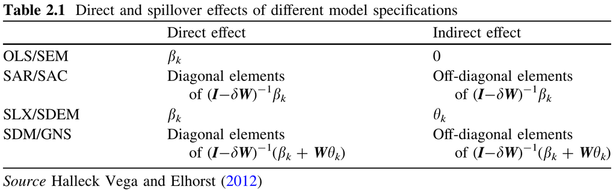

Fuente: Elhorst (2013)

## Ejemplo con datos simulados

- Para simular un modelo SAR, podemos seguir los siguientes pasos:
  1. Generar una matriz de covariables $X$ junto con sus respectivos coeficientes,
  2. Generar un vector $\varepsilon \sim N(0,1)$, pregunta: ¿Importa no utilizar la función MVN (`mvtnorm::rmvnorm`)?
  3. Generar el vector $Y$ de la siguiente forma:

     $$Y = \left(I_n -\rho W\right)^{-1}(\alpha + X\beta + \varepsilon)$$

     Donde $I_n$ es una matriz diagonal $n$.

## Ejemplo con datos simulados (cont.)

Para más información sobre los objetos `nb` ver la sección *9.2 Spatial Neighbours* del libro *Applied spatial data analysis with R* (Bivand et al. 2008).

```r
# Parametros para la simulacion
set.seed(1151)
n   <- 500L
k   <- 2L
rho <- .5

# Simulando covariables y coeficientes
X   <- matrix(runif(n*k), ncol=k)
b   <- cbind(runif(k + 1L, -1, 1))
eps <- cbind(rnorm(n))
```

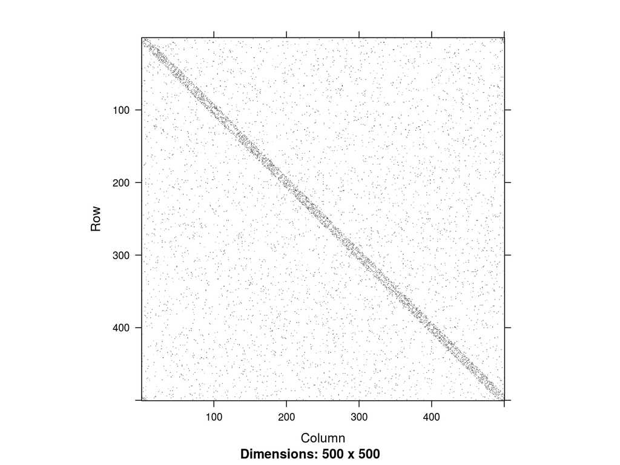

```r
# Simulando matriz espacial, utilizaremos el paquete igraph para esto
library(igraph)
library(Matrix) # Para acceder al dgCMatrix en la funcion rowSums

# Modelo mundo pequeño parametros 8 (numero de vecinos) y .4 (probabilidad) de
# re-cableo.
net <- igraph::sample_smallworld(1, n, 8, .4)
W   <- as_adj(net)

# Normalizando matriz y visualizando
W   <- W/rowSums(W)
image(W)
```

```r
# Generando variable dependiente
Y <- as.matrix(solve(diag(n) - rho*W) %*% (cbind(1, X) %*% b + eps))

# La I de moran
netdiffuseR::moran(Y, W)
```

```
## $observed
## [1] 0.06129765
##
## $expected
## [1] -0.002004008
##
## $sd
## [1] 0.01574654
##
## $p.value
## [1] 5.818925e-05
##
## attr(,"class")
## [1] "diffnet_moran"
```

```r
# OBS: La implentacion en netdiffuseR es significativamente mas rapida que la del
# paquete spdep (~ 100 veces en mi maquina).
# Wlist <- mat2listw(W)
# microbenchmark::microbenchmark(
#   netdiffuseR::moran(Y, W), # Para matrices realmente grandes
#   moran.test(Y, Wlist, alternative = "two.sided")
# )
```

```r
library(spdep) # Para el test de moran
# Naive OLS
ans0 <- lm(Y ~ X)
lm.morantest(ans0, listw = mat2listw(W)) # netdiffuseR::moran(ans0$residuals, W)
```

```
##
##  Global Moran I for regression residuals
##
## data:
## model: lm(formula = Y ~ X)
## weights: mat2listw(W)
##
## Moran I statistic standard deviate = 3.8427, p-value = 6.083e-05
## alternative hypothesis: greater
## sample estimates:
## Observed Moran I      Expectation         Variance
##     0.0585159288    -0.0019892122     0.0002479145
```

```r
# Modelos de regresion
WY <- as.matrix(W %*% Y)
ans1 <- lm(Y ~ WY + X) # Coeficiente sesgado
ans1
```

```
##
## Call:
## lm(formula = Y ~ WY + X)
##
## Coefficients:
## (Intercept)           WY           X1           X2
##      0.2071       0.8617      -0.6369      -0.1389
```

```r
# Modelos SAR
library(spdep)
(ans2 <- lagsarlm(Y ~ X, listw = mat2listw(W))) # Especificacion correcta
```

```
##
## Call:
## lagsarlm(formula = Y ~ X, listw = mat2listw(W))
## Type: lag
##
## Coefficients:
##         rho (Intercept)          X1          X2
##   0.4528325  -0.3248790  -0.6589936  -0.1383480
##
## Log likelihood: -735.6626
```

```r
(ans3 <- lagsarlm(Y ~ X, listw = mat2listw(W), Durbin = ~ X[,-1])) # Especificacion incorrecta
```

```
##
## Call:
## lagsarlm(formula = Y ~ X, listw = mat2listw(W), Durbin = ~X[,
##     -1])
## Type: mixed
##
## Coefficients:
##         rho (Intercept)          X1          X2      lag.X1      lag.X2
##  0.44622671 -0.11673673 -0.66330614 -0.14644768 -0.47972971  0.04760732
##
## Log likelihood: -735.3998
```

```r
texreg::htmlreg(list(ans0, ans1, ans2, ans3), doctype = FALSE)
```

Statistical models

|  | **Model 1** | **Model 2** | **Model 3** | **Model 4** |  |
| --- | --- | --- | --- | --- | --- |
| (Intercept) | -0.91*** | 0.21 | -0.32 | -0.12 |  |
|  | (0.13) | (0.25) | (0.20) | (0.51) |  |
| X1 | -0.68*** | -0.64*** | -0.66*** | -0.66*** |  |
|  | (0.17) | (0.17) | (0.17) | (0.17) |  |
| X2 | -0.14 | -0.14 | -0.14 | -0.15 |  |
|  | (0.16) | (0.16) | (0.16) | (0.16) |  |
| WY |  | 0.86*** |  |  |  |
|  |  | (0.16) |  |  |  |
| rho |  |  | 0.45*** | 0.45*** |  |
|  |  |  | (0.12) | (0.12) |  |
| lag.X1 |  |  |  | -0.48 |  |
|  |  |  |  | (0.67) |  |
| lag.X2 |  |  |  | 0.05 |  |
|  |  |  |  | (0.64) |  |
| R<sup>2</sup> | 0.03 | 0.08 |  |  |  |
| Adj. R<sup>2</sup> | 0.03 | 0.08 |  |  |  |
| Num. obs. | 500 | 500 | 500 | 500 |  |
| RMSE | 1.07 | 1.04 |  |  |  |
| Parameters |  |  | 5 | 7 |  |
| Log Likelihood |  |  | -735.66 | -735.40 |  |
| AIC (Linear model) |  |  | 1493.43 | 1496.11 |  |
| AIC (Spatial model) |  |  | 1481.33 | 1484.80 |  |
| LR test: statistic |  |  | 14.10 | 13.31 |  |
| LR test: p-value |  |  | 0.00 | 0.00 |  |
| p < 0.001, p < 0.01, p < 0.05 |  |  |  |  |  |

## Bibliografía

Bivand, Roger S, Edzer J Pebesma, Virgilio Gomez-Rubio, and Edzer Jan Pebesma. 2008. *Applied Spatial Data Analysis with R*. Vol. 747248717. Springer.

Elhorst, J.P. 2013. *Spatial Econometrics: From Cross-Sectional Data to Spatial Panels*. SpringerBriefs in Regional Science. Springer Berlin Heidelberg. https://books.google.cl/books?id=mu25BAAAQBAJ.

Kelejian, Harry H., and Ingmar R. Prucha. 2010. “Specification and estimation of spatial autoregressive models with autoregressive and heteroskedastic disturbances.” *Journal of Econometrics* 157 (1): 53–67. https://doi.org/10.1016/j.jeconom.2009.10.025.

LeSage, James P. 2008. “An Introduction to Spatial Econometrics.” *Revue d’économie Industrielle* 123 (123): 19–44. https://doi.org/10.4000/rei.3887.

LeSage, James P., and R Kelley Pace. 2014. “The Biggest Myth in Spatial Econometrics.” *Econometrics* 2 (4): 217–49. https://doi.org/10.2139/ssrn.1725503.

Moran, P. A. P. 1950. “Notes on Continuous Stochastic Phenomena.” *Biometrika* 37 (1/2): 17. https://doi.org/10.2307/2332142.

Piras, Gianfranco. 2010. “sphet: Spatial Models with Heteroskedastic Innovations in R.” *Journal of Statistical Software* 35 (4): 1–21. https://doi.org/10.1016/j.landurbplan.2011.01.013.

Ripley, Ruth M, Tom AB Snijders, Zsofia Boda, András Vörös, and Paulina Preciado. 2011. “Manual for Rsiena.” *University of Oxford, Department of Statistics, Nuffield College* 1.

Snijders, Tom A B, Gerhard G. van de Bunt, and Christian E G Steglich. 2010. “Introduction to stochastic actor-based models for network dynamics.” *Social Networks* 32 (1): 44–60. https://doi.org/10.1016/j.socnet.2009.02.004.

Steglich, Christian, Tom A. B. Snijders, and Michael Pearson. 2010. “8. Dynamic Networks and Behavior: Separating Selection from Influence.” *Sociological Methodology* 40 (1): 329–93. https://doi.org/10.1111/j.1467-9531.2010.01225.x.